# campsisnca

[figure not shown]

[figure not shown]

Analyse your simulation output using non-compartmental analysis.

## Installation

Install the latest stable release as follows:

```r
devtools::install_github("Calvagone/campsisnca")
```

## Basic use

First import the `campsisnca` and `gtsummary` packages as follows:

```r
library(campsisnca)
library(gtsummary)
library(gt)
```

### Example 1: PK metrics at Day 1 and Day 7

Assume some results were simulated with Campsis (see `campsis` dataframe) :

```r
campsis <- generate_test_data()
campsis
```

```
## # A tibble: 5,000 × 16
##       ID  TIME   ARM   A_DEPOT A_CENTRAL A_PERIPHERAL A_OUTPUT    BW    CL    V2
##    <dbl> <dbl> <dbl>     <dbl>     <dbl>        <dbl>    <dbl> <dbl> <dbl> <dbl>
##  1     1     0     0   0              0           0        0    93.6  5.89  94.8
##  2     1     1     0   4.31e+2      538.         11.3     19.4  93.6  5.89  94.8
##  3     1     2     0   1.86e+2      722.         32.4     59.7  93.6  5.89  94.8
##  4     1     4     0   3.44e+1      741.         71.7    153.   93.6  5.89  94.8
##  5     1     6     0   6.39e+0      657.         96.3    240.   93.6  5.89  94.8
##  6     1     8     0   1.19e+0      574.        108.     316.   93.6  5.89  94.8
##  7     1    12     0   4.09e-2      447.        110.     442.   93.6  5.89  94.8
##  8     1    16     0   1.41e-3      358.         99.8    542.   93.6  5.89  94.8
##  9     1    24     0   1.67e-6      239.         72.7    688.   93.6  5.89  94.8
## 10     1    48     0   1.67e-6      316.         96.4   1588.   93.6  5.89  94.8
## # ℹ 4,990 more rows
## # ℹ 6 more variables: Q <dbl>, V3 <dbl>, KA <dbl>, CP <dbl>, OBS_CP <dbl>,
## #   Y <dbl>
```

Let’s define our PK metrics at Day 1 and Day 7 as follows:

```r
# Day 1
nca_d1 <- NCAAnalysis(name = "Day 1", window = TimeWindow(0, 24), variable = "Y") %>%
  add(c(AUC(unit = "ng/mL*h"), Cmax(unit = "ng/mL"), Tmax(unit = "h"), Ctrough(unit = "ng/mL")))

# Day 7
nca_d7 <- NCAAnalysis(name = "Day 7", window = TimeWindow(144, 168), variable = "Y") %>%
  add(c(AUC(), Cmax(), Tmax(), Ctrough()))
```

These 2 metrics may be imported into a metrics table object, as follows. Use the `calculate` method to calculate the metrics in the table.

```r
table <- NCATable() %>%
  add(c(nca_d1, nca_d7)) %>%
  calculate(campsis)
```

This table can be exported:

1. To a dataframe using the `export` function:

```r
table %>% export(dest = "dataframe")
```

```
## # A tibble: 24 × 4
##    metric  stat    value analysis
##    <chr>   <chr>   <dbl> <chr>
##  1 AUC     median 134.   Day 1
##  2 AUC     p5     102.   Day 1
##  3 AUC     p95    168.   Day 1
##  4 Cmax    median  10.2  Day 1
##  5 Cmax    p5       7.85 Day 1
##  6 Cmax    p95     13.1  Day 1
##  7 tmax    median   2    Day 1
##  8 tmax    p5       1    Day 1
##  9 tmax    p95      6    Day 1
## 10 Ctrough median   2.89 Day 1
## # ℹ 14 more rows
```

When `type` is not specified, default value is `summary`. Argument `type` can also be `summary_wide` or `summary_pretty`. In the latter case, summary statistics are exported according to the arguments `stat_display` and `digits` provided for each metric.

2. To an HTML table using `gt`:

```r
table %>% export(dest = "gt") %>% as_raw_html()
```

| **Metric** | **Day 1** N = 200<sup>1</sup> | **Day 7** N = 200<sup>1</sup> |
| --- | --- | --- |
| AUC (ng/mL*h) | 134 (102–168) | 199 (131–297) |
| C<sub>max</sub> (ng/mL) | 10.2 (7.8–13.1) | 14.8 (10.4–20.6) |
| t<sub>max</sub> (h) | 2.00 (1.00–6.00) | 2.00 (1.00–6.00) |
| C<sub>trough</sub> (ng/mL) | 2.89 (1.43–4.50) | 4.18 (1.99–8.75) |

<sup>1</sup> Median (5% Centile–95% Centile)

Please note the individual metrics can also be exported to a dataframe using the `export` function as follows:

```r
table %>% export(dest = "dataframe", type = "individual_wide")
```

```
## # A tibble: 400 × 6
##       id analysis   AUC  Cmax  tmax Ctrough
##    <dbl> <chr>    <dbl> <dbl> <dbl>   <dbl>
##  1     1 Day 1    122.   9.78     4    2.75
##  2     2 Day 1     92.6  6.11     6    1.70
##  3     3 Day 1    119.  10.9      2    1.97
##  4     4 Day 1    131.   9.72     2    1.99
##  5     5 Day 1    166.  10.1      4    3.79
##  6     6 Day 1    152.  10.1      2    3.04
##  7     7 Day 1    134.   9.28     2    2.70
##  8     8 Day 1    163.  13.7      2    2.91
##  9     9 Day 1    111.   9.62     2    1.94
## 10    10 Day 1    118.   9.91     4    2.90
## # ℹ 390 more rows
```

### Example 2: PK metrics at Day 1 and Day 7 for different body weight ranges

```r
library(dplyr)
campsis_ <- campsis %>%
  mutate(Scenario = ifelse(BW >= 75, ">=75kg patients", "<75kg patients"))

day1 <- NCAAnalysis(name = "Day 1", window = TimeWindow(0, 24), variable = "Y", strata = c(Scenario = "all")) %>%
  add(c(AUC(unit = "ng/mL*h"), Cmax(unit = "ng/mL"), Tmax(unit = "h"), Ctrough(unit = "ng/mL")))

day7 <- NCAAnalysis(name = "Day 7", window = TimeWindow(144, 168), variable = "Y", strata = c(Scenario = "all")) %>%
  add(c(AUC(), Cmax(), Tmax(), Ctrough()))

table <- NCATable() %>%
  add(c(day1, day7)) %>%
  calculate(campsis_)

table %>% export(dest = "gt") %>% as_raw_html()
```

| **Metric** | **>=75kg patients** N = 97<sup>1</sup> | **<75kg patients** N = 103<sup>1</sup> |
| --- | --- | --- |
| Day 1 |  |  |
| AUC (ng/mL*h) | 122 (98–154) | 144 (120–174) |
| C<sub>max</sub> (ng/mL) | 10.17 (7.47–12.80) | 10.26 (8.23–13.42) |
| t<sub>max</sub> (h) | 2.00 (1.00–6.00) | 2.00 (1.00–6.00) |
| C<sub>trough</sub> (ng/mL) | 2.24 (1.25–3.90) | 3.46 (2.20–4.60) |
| Day 7 |  |  |
| AUC (ng/mL*h) | 168 (121–236) | 233 (164–305) |
| C<sub>max</sub> (ng/mL) | 13.4 (9.9–18.4) | 16.4 (12.6–21.1) |
| t<sub>max</sub> (h) | 2.00 (1.00–6.00) | 2.00 (1.00–6.00) |
| C<sub>trough</sub> (ng/mL) | 3.23 (1.27–5.85) | 5.95 (3.03–9.21) |

<sup>1</sup> Median (5% Centile–95% Centile)

```r
# Alternatively, first stratification variable can be seen in columns (use of 'tbl_merge' within gtsummary)
table <- NCATable(combine_with = "tbl_merge") %>%
  add(c(day1, day7)) %>%
  calculate(campsis_)

table %>% export(dest = "gt") %>% as_raw_html()
```

| **Metric** | **Day 1** **>=75kg patients** N = 97<sup>1</sup> | **Day 1** **<75kg patients** N = 103<sup>1</sup> | **Day 7** **>=75kg patients** N = 97<sup>1</sup> | **Day 7** **<75kg patients** N = 103<sup>1</sup> |
| --- | --- | --- | --- | --- |
| AUC (ng/mL*h) | 122 (98–154) | 144 (120–174) | 168 (121–236) | 233 (164–305) |
| C<sub>max</sub> (ng/mL) | 10.17 (7.47–12.80) | 10.26 (8.23–13.42) | 13.4 (9.9–18.4) | 16.4 (12.6–21.1) |
| t<sub>max</sub> (h) | 2.00 (1.00–6.00) | 2.00 (1.00–6.00) | 2.00 (1.00–6.00) | 2.00 (1.00–6.00) |
| C<sub>trough</sub> (ng/mL) | 2.24 (1.25–3.90) | 3.46 (2.20–4.60) | 3.23 (1.27–5.85) | 5.95 (3.03–9.21) |

<sup>1</sup> Median (5% Centile–95% Centile)

### Example 3: Calculate 2-compartment half-life metrics

```r
nca <- NCAAnalysis(variable = "Y") %>%
  add(c(Thalf.2cpt.dist(), Thalf.2cpt.eff(), Thalf.2cpt.z()))

table <- NCATable() %>%
  add(nca) %>%
  calculate(campsis %>% mutate(DOSE = 1000, TAU = 24))

table %>% export(dest = "gt") %>% as_raw_html()
```

| **Metric** | **N = 200**<sup>1</sup> |
| --- | --- |
| t<sub>½,dist</sub> | 2.57 (1.91–3.51) |
| t<sub>½,eff</sub> | 13.4 (8.3–21.1) |
| t<sub>½,z</sub> | 14.6 (9.6–22.7) |

<sup>1</sup> Median (5% Centile–95% Centile)

### Example 4: Compute terminal half-live based on data

```r
nca <- NCAAnalysis(variable = "Y") %>%
  add(c(Thalf(window = TimeWindow(7 * 24, 10 * 24))))

table <- NCATable() %>%
  add(nca) %>%
  calculate(campsis)

table %>% export(dest = "gt") %>% as_raw_html()
```

| **Metric** | **N = 200**<sup>1</sup> |
| --- | --- |
| t<sub>½</sub> | 14.5 (9.7–22.1) |

<sup>1</sup> Median (5% Centile–95% Centile)

### Example 5: Round your PK metrics

```r
# Day 1
nca_d1 <- NCAAnalysis(name = "Day 1", window = TimeWindow(0, 24), variable = "Y") %>%
  add(AUC(digits = ~ style_sigfig(.x, 2), name = "AUC1")) %>% # At least 2 significant figures (default in gtsummary)
  add(AUC(digits = c(1, 2, 2), name = "AUC2")) %>% # Respectively 1/2/2 digit(s) after decimal for med, p5 and p95
  add(AUC(digits = ~ signif(.x, 2), name = "AUC3")) %>% # 2 significant digits only
  add(AUC(digits = list(~ round(.x / 5) * 5, ~ round(.x, 1), ~ style_number(.x)), name = "AUC4")) # 1 specific function for med, p5 and p95

# Day 7
nca_d7 <- NCAAnalysis(name = "Day 7", window = TimeWindow(144, 168), variable = "Y") %>%
  add(AUC(name = "AUC1")) %>%
  add(AUC(name = "AUC2")) %>%
  add(AUC(name = "AUC3")) %>%
  add(AUC(name = "AUC4"))

table <- NCATable()
table <- table %>%
  add(c(nca_d1, nca_d7)) %>%
  calculate(campsis)

table %>% export(dest = "gt") %>% as_raw_html()
```

| **Metric** | **Day 1** N = 200<sup>1</sup> | **Day 7** N = 200<sup>1</sup> |
| --- | --- | --- |
| AUC1 | 134 (102–168) | 199 (131–297) |
| AUC2 | 134.0 (102.03–167.51) | 199.4 (130.64–296.69) |
| AUC3 | 130 (100–170) | 200 (130–300) |
| AUC4 | 135 (102–168) | 200 (130.6–297) |

<sup>1</sup> Median (5% Centile–95% Centile)

### Example 6: Export custom metrics (including categorical data)

```r
# Compute Cmax yourself using campsisnca
custom1 <- CustomMetric(fun = ~ Cmax() %>% i_value(.x, .y), name = "C_{max} custom", unit = "ng/mL")

# Check if Cmax if higher than 12 ng/mL
custom2 <- CustomMetric(
  fun = ~ (Cmax() %>% i_value(.x, .y)) > 12,
  name = "C_{max} > 12",
  unit = "%",
  categorical = TRUE
)

# Shortcut notation is also accepted
custom3 <- CustomMetric(fun = ~ Cmax > 13, name = "C_{max}> 13", unit = "%", categorical = TRUE)


# Day 1
nca_d1 <- NCAAnalysis(name = "Day 1", window = TimeWindow(0, 24), variable = "Y") %>%
  add(c(Cmax(unit = "ng/mL"), Tmax(unit = "h"), custom1, custom2, custom3))

# Day 7
nca_d7 <- NCAAnalysis(name = "Day 7", window = TimeWindow(144, 168), variable = "Y") %>%
  add(c(Cmax(), Tmax(), custom1, custom2, custom3))

table <- NCATable()
table <- table %>%
  add(c(nca_d1, nca_d7)) %>%
  calculate(campsis)

table %>% export(dest = "gt") %>% as_raw_html()
```

| **Metric** | **Day 1** N = 200<sup>1</sup> | **Day 7** N = 200<sup>1</sup> |
| --- | --- | --- |
| C<sub>max</sub> (ng/mL) | 10.2 (7.8–13.1) | 14.8 (10.4–20.6) |
| t<sub>max</sub> (h) | 2.00 (1.00–6.00) | 2.00 (1.00–6.00) |
| C<sub>max</sub> custom (ng/mL) | 10.2 (7.8–13.1) | 14.8 (10.4–20.6) |
| C<sub>max</sub> > 12 (%) | 31 / 200 (16%) | 164 / 200 (82%) |
| C<sub>max</sub>> 13 (%) | 12 / 200 (6.0%) | 149 / 200 (75%) |

<sup>1</sup> Median (5% Centile–95% Centile); n / N (%)

```r
# Alternatively, all dichotomous levels can be shown as well:
table <- NCATable(show_all_levels = TRUE)
table <- table %>%
  add(c(nca_d1, nca_d7)) %>%
  calculate(campsis)

table %>% export(dest = "gt") %>% as_raw_html()
```

| **Metric** | **Day 1** N = 200<sup>1</sup> | **Day 7** N = 200<sup>1</sup> |
| --- | --- | --- |
| C<sub>max</sub> (ng/mL) | 10.2 (7.8–13.1) | 14.8 (10.4–20.6) |
| t<sub>max</sub> (h) | 2.00 (1.00–6.00) | 2.00 (1.00–6.00) |
| C<sub>max</sub> custom (ng/mL) | 10.2 (7.8–13.1) | 14.8 (10.4–20.6) |
| C<sub>max</sub> > 12 (%) |  |  |
| FALSE | 169 / 200 (85%) | 36 / 200 (18%) |
| TRUE | 31 / 200 (16%) | 164 / 200 (82%) |
| C<sub>max</sub>> 13 (%) |  |  |
| FALSE | 188 / 200 (94%) | 51 / 200 (26%) |
| TRUE | 12 / 200 (6.0%) | 149 / 200 (75%) |

<sup>1</sup> Median (5% Centile–95% Centile); n / N (%)

### Example 7: Geometric mean / Geometric CV

```r
nca <- NCAAnalysis(variable = "Y") %>%
  add(c(
    AUC(unit = "ng/mL*h", stat_display = "{geomean} ({geocv}%)"),
    Cavg(unit = "ng/mL", stat_display = "{geomean} ({geocv}%)")
  ))

table <- NCATable() %>%
  add(nca) %>%
  calculate(campsis)

table %>% export(dest = "gt") %>% as_raw_html()
```

| **Metric** | **N = 200**<sup>1</sup> |
| --- | --- |
| AUC (ng/mL*h) | 909 (35%) |
| C<sub>avg</sub> (ng/mL) | 3.79 (35.17%) |

<sup>1</sup> geomean (geocv%)

### Example 8: Statistics on categorical data with more than 2 levels

```r
get_category <- function(.x, .y) {
  values <- Cmax() %>% i_value(.x, .y)
  retValue <- dplyr::case_when(
    values < 10 ~ "(1) < 10 ng/mL",
    values >= 10 & values <= 15 ~ "(2) 10-15 ng/mL",
    values > 15 ~ "(3) > 15 ng/mL",
  )
  return(retValue)
}

# Or equivalently, the 1-line purrr-style lambda expression
# get_category <- ~case_when(Cmax < 10 ~ "(1) < 10 ng/mL", Cmax >= 10 & Cmax <= 15 ~ "(2) 10-15 ng/mL", Cmax > 15 ~ "(3) > 15 ng/mL")

# Day 1
nca_d1 <- NCAAnalysis(name = "Day 1", window = TimeWindow(0, 1, time_unit = "day"), variable = "Y") %>%
  add(Cmax(unit = "ng/mL")) %>%
  add(CustomMetric(fun = get_category, name = "C_{max} categories", unit = "%", categorical = TRUE))

# Day 7
nca_d7 <- NCAAnalysis(name = "Day 7", window = TimeWindow(6, 7, time_unit = "day"), variable = "Y") %>%
  add(Cmax()) %>%
  add(CustomMetric(fun = get_category, name = "C_{max} categories", unit = "%", categorical = TRUE))

table <- NCATable()
table <- table %>%
  add(c(nca_d1, nca_d7)) %>%
  calculate(campsis)

table %>% export(dest = "gt") %>% as_raw_html()
```

| **Metric** | **Day 1** N = 200<sup>1</sup> | **Day 7** N = 200<sup>1</sup> |
| --- | --- | --- |
| C<sub>max</sub> (ng/mL) | 10.2 (7.8–13.1) | 14.8 (10.4–20.6) |
| C<sub>max</sub> categories (%) |  |  |
| (1) < 10 ng/mL | 87 / 200 (44%) | 6 / 200 (3.0%) |
| (2) 10-15 ng/mL | 111 / 200 (56%) | 96 / 200 (48%) |
| (3) > 15 ng/mL | 2 / 200 (1.0%) | 98 / 200 (49%) |

<sup>1</sup> Median (5% Centile–95% Centile); n / N (%)

### Example 9: Time above or below a certain threshold

In the example below, we look at the individual time above (or below) 10 ng/mL at Day 1 for the 10 first subjects.

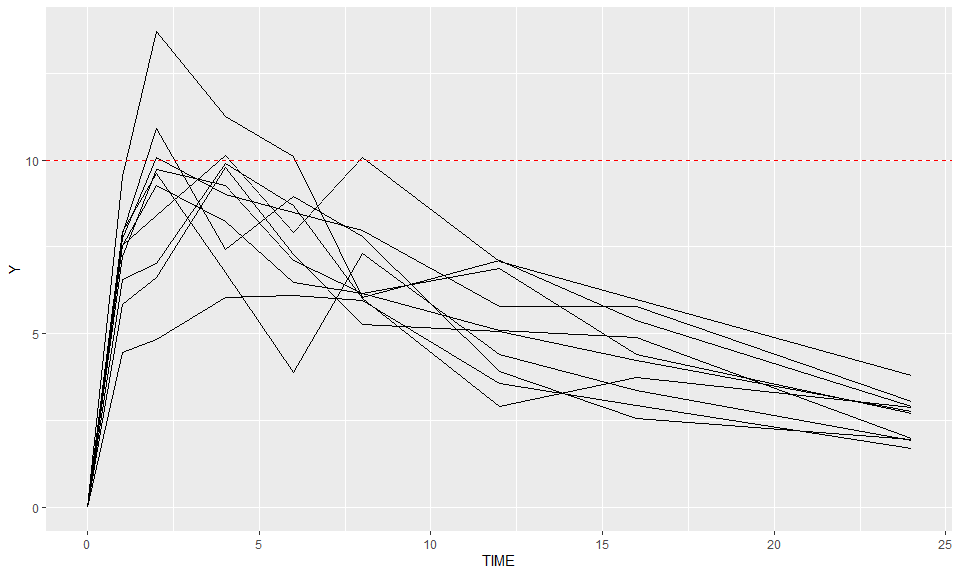

```r
day1 <- campsis %>%
  timerange(0, 24) %>%
  filter(ID %in% (1:10))

campsis::spaghettiPlot(day1, "Y") +
  ggplot2::geom_hline(yintercept = 10, linetype = "dashed", color = "red")
```

```r
nca <- NCAAnalysis(window = TimeWindow(0, 24), variable = "Y") %>%
  add(Cmax(unit = "ng/mL*h", stat_display = "{mean}")) %>%
  add(TimeAboveLimit(limit = 10, unit = "h", stat_display = "{mean}")) %>%
  add(TimeBelowLimit(limit = 10, unit = "h", stat_display = "{mean}"))

table <- NCATable() %>%
  add(nca) %>%
  calculate(campsis %>% filter(ID %in% (1:10)))

table %>% export(dest = "dataframe", type = "individual_wide")
```

```
## # A tibble: 10 × 4
##       id  Cmax `Time above 10` `Time below 10`
##    <dbl> <dbl>           <dbl>           <dbl>
##  1     1  9.78           0                24
##  2     2  6.11           0                24
##  3     3 10.9            0.829            23.2
##  4     4  9.72           0                24
##  5     5 10.1            0.427            23.6
##  6     6 10.1            0.186            23.8
##  7     7  9.28           0                24
##  8     8 13.7            4.94             19.1
##  9     9  9.62           0                24
## 10    10  9.91           0                24
```

Summary statistics can also be exported:

```r
table %>% export(dest = "gt") %>% as_raw_html()
```

| **Metric** | **N = 10**<sup>1</sup> |
| --- | --- |
| C<sub>max</sub> (ng/mL*h) | 9.93 |
| Time above 10 (h) | 0.64 |
| Time below 10 (h) | 23.36 |

<sup>1</sup> Mean

### Example 10: Summary statistics across arms and scenarios

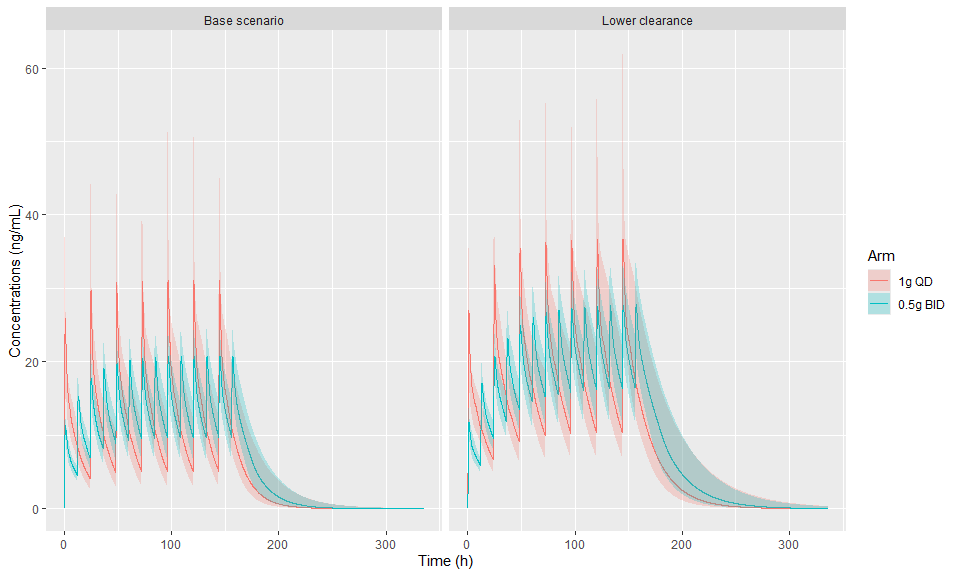

```r
library(campsis)
arm1 <- Arm(subjects = 24, label = "1g QD") %>%
  add(Bolus(time = 0, amount = 1000, compartment = "ABS", ii = 24, addl = 6)) %>%
  add(Observations(seq(0, 14 * 24, by = 0.1))) # 2-weeks observations

arm2 <- Arm(subjects = 24, label = "0.5g BID") %>%
  add(Bolus(time = 0, amount = 500, compartment = "ABS", ii = 12, addl = 13)) %>%
  add(Observations(seq(0, 14 * 24, by = 0.1))) # 2-weeks observations

dataset <- Dataset() %>%
  add(c(arm1, arm2))

scenario1 <- Scenario(name = "Base scenario", model = ~.x, dataset = ~.x)
scenario2 <- Scenario(
  name = "Lower clearance",
  model = ~ .x %>%
    replace(Theta(name = "CL", value = 2)),
  dataset = ~.x
)
scenarios <- Scenarios() %>% add(c(scenario1, scenario2))
results <- simulate(
  model = model_suite$pk$`2cpt_fo`,
  dataset = dataset,
  seed = 1,
  dest = "mrgsolve",
  scenarios = scenarios
)

shadedPlot(results, "CONC", colour = "ARM", strat_extra = "SCENARIO") +
  ggplot2::facet_wrap(~SCENARIO) +
  ggplot2::xlab("Time (h)") +
  ggplot2::ylab("Concentrations (ng/mL)") +
  ggplot2::labs(colour = "Arm", fill = "Arm")
```

NCA summary statistics are automatically calculated across all strata levels in ARM and SCENARIO.

```r
nca <- NCAAnalysis(name = "Day 7", window = TimeWindow(144, 168), variable = "CONC") %>%
  add(AUC(unit = "ng/mL*h")) %>%
  add(Cmax(unit = "ng/mL")) %>%
  add(CustomMetric(
    fun = ~ (Cmax() %>% i_value(.x, .y)) > 30,
    name = "C_{max} > 30",
    unit = "%",
    categorical = TRUE
  )) %>%
  add(Tmax(unit = "h", digits = 2)) %>%
  add(Ctrough(unit = "ng/mL")) %>%
  add(Thalf(unit = "h", window = TimeWindow(200, "last"))) # Thalf will be estimated by dosing a linear regression on the range [200, 'last']

table <- NCATable() %>%
  add(nca) %>%
  calculate(results)

table %>% export(dest = "gt") %>% as_raw_html()
```

| **Metric** | **1g QD** N = 24<sup>1</sup> | **0.5g BID** N = 24<sup>1</sup> |
| --- | --- | --- |
| Base scenario |  |  |
| AUC (ng/mL*h) | 305 (230–543) | 338 (254–467) |
| C<sub>max</sub> (ng/mL) | 31 (23–53) | 21 (16–25) |
| C<sub>max</sub> > 30 (%) | 15 / 24 (63%) | 0 / 24 (0%) |
| t<sub>max</sub> (h) | 0.80 (0.50–1.70) | 12.80 (12.60–13.20) |
| C<sub>trough</sub> (ng/mL) | 5.1 (3.1–13.2) | 9.7 (6.8–15.2) |
| t<sub>½</sub> (h) | 14.24 (12.89–19.87) | 13.44 (12.10–18.15) |
| Lower clearance |  |  |
| AUC (ng/mL*h) | 457 (344–805) | 506 (381–691) |
| C<sub>max</sub> (ng/mL) | 37 (28–64) | 28 (22–34) |
| C<sub>max</sub> > 30 (%) | 21 / 24 (88%) | 6 / 24 (25%) |
| t<sub>max</sub> (h) | 0.80 (0.50–1.90) | 12.85 (12.70–13.30) |
| C<sub>trough</sub> (ng/mL) | 10.4 (7.0–23.5) | 16.5 (11.9–24.6) |
| t<sub>½</sub> (h) | 15.9 (12.5–28.5) | 17.9 (12.0–26.7) |

<sup>1</sup> Median (5% Centile–95% Centile); n / N (%)

In the previous example, statistics are summarized on Day 7. In you wish specifics statistics for each one of your arms, you could also proceed sightly differently by creating 2 analyses (1 for each strata) and refer to specific arms by overriding the default strata.

```r
nca_arm1 <- NCAAnalysis(
  name = "Last dose in '1g QD' arm",
  window = TimeWindow(144, 168),
  variable = "CONC",
  strata = c(ARM = "1g QD", SCENARIO = "all")
) %>%
  add(AUC(unit = "ng/mL*h")) %>%
  add(Cmax(unit = "ng/mL")) %>%
  add(CustomMetric(
    fun = ~ (Cmax() %>% i_value(.x, .y)) > 30,
    name = "C_{max} > 30",
    unit = "%",
    categorical = TRUE
  )) %>%
  add(Tmax(unit = "h", digits = 2)) %>%
  add(Ctrough(unit = "ng/mL")) %>%
  add(Thalf(unit = "h", window = TimeWindow(200, "last")))

nca_arm2 <- NCAAnalysis(
  name = "Last dose in '0.5 BID' arm",
  window = TimeWindow(156, 168),
  variable = "CONC",
  strata = c(ARM = "0.5g BID", SCENARIO = "all")
) %>%
  add(AUC(unit = "ng/mL*h")) %>%
  add(Cmax(unit = "ng/mL")) %>%
  add(CustomMetric(
    fun = ~ (Cmax() %>% i_value(.x, .y)) > 30,
    name = "C_{max} > 30",
    unit = "%",
    categorical = TRUE
  )) %>%
  add(Tmax(unit = "h", digits = 2)) %>%
  add(Ctrough(unit = "ng/mL")) %>%
  add(Thalf(unit = "h", window = TimeWindow(200, "last")))

table <- NCATable() %>%
  add(nca_arm1) %>%
  add(nca_arm2) %>%
  calculate(results)

table %>% export(dest = "gt") %>% as_raw_html()
```

| **Metric** | **Base scenario** N = 24<sup>1</sup> | **Lower clearance** N = 24<sup>1</sup> |
| --- | --- | --- |
| Last dose in '1g QD' arm |  |  |
| AUC (ng/mL*h) | 305 (230–543) | 457 (344–805) |
| C<sub>max</sub> (ng/mL) | 31 (23–53) | 37 (28–64) |
| C<sub>max</sub> > 30 (%) | 15 / 24 (63%) | 21 / 24 (88%) |
| t<sub>max</sub> (h) | 0.80 (0.50–1.70) | 0.80 (0.50–1.90) |
| C<sub>trough</sub> (ng/mL) | 5.1 (3.1–13.2) | 10.4 (7.0–23.5) |
| t<sub>½</sub> (h) | 14.2 (12.9–19.9) | 15.9 (12.5–28.5) |
| Last dose in '0.5 BID' arm |  |  |
| AUC (ng/mL*h) | 169 (127–234) | 253 (191–346) |
| C<sub>max</sub> (ng/mL) | 20.7 (15.8–24.7) | 27.7 (21.5–34.0) |
| C<sub>max</sub> > 30 (%) | 0 / 24 (0%) | 6 / 24 (25%) |
| t<sub>max</sub> (h) | 0.80 (0.60–1.20) | 0.85 (0.70–1.30) |
| C<sub>trough</sub> (ng/mL) | 9.7 (6.8–15.2) | 16.5 (11.9–24.6) |
| t<sub>½</sub> (h) | 13.4 (12.1–18.2) | 17.9 (12.0–26.7) |

<sup>1</sup> Median (5% Centile–95% Centile); n / N (%)